# Trabajo Final

Bladimir Carabali

9/29/2021

```r
# Global options
options(stringsAsFactors = FALSE)
```

```r
# Cargas de librerías
library(quanteda)
library(tidyverse)
library(quanteda.textstats)
library(stringr)
library(knitr)
library(quanteda.textplots)
```

### Exploración de noticias sobre violencia en la ciudad de Buenaventura-Colombia.

#### Introducción

En Colombia desde su constitución como Republica se han mas presentado más de cinco guerras civiles (Palacios, 2012). Ahora bien, desde la mitad del siglo XX se inició una consolidación de diferentes grupos armados, como las Fuerzas Armadas Revolucionarias de Colombiana (FARC), Ejercicito de Liberación Nacional (ELN), Ejercicito de Liberación Popular (EPL), grupos paramilitares y Narcotraficantes. Sin embargo, las confrontaciones armadas entre las fuerzas del Estado y los grupos armados no suscitada en todo el territorio colombiano. Los nuevos escenarios de guerras suscitaron desde los años noventa, se incorporaron nuevas regiones colombianas como el litoral Pacífico, donde se encuentra la ciudad de Buenaventura-Colombia. Esta región localizada en un área geoestratégica para el impulso de las economías legal e ilegal en Colombia contrasta con sus alarmantes niveles de pobreza, los cuales sobrepasan la media nacional, pese a estar durante mucho tiempo libre de la guerra de mitad del XX aunque sumida en el total abandono estatal (Escobar, 2004; Agudelo, 2001).

el territorio de Buenaventura (Colombia) no responde de la misma manera o similarmente a lo suscitado en otras partes del país. Mientras que en otras zonas de Colombia la intensidad de la guerra posiblemente aumentaba, en esta ciudad se construía la plataforma logística para la exportaciones e importaciones de bienes y servicios de la economía colombiana. En dicho contexto de violencia motivada en la ciudad de Buenaventura desde años 90’ hasta 2021, este trabajo se intenta mostrar las palabras mas frecuentes en una de las plataformas de noticias en web más importante de la ciudad. Para dicho ejercicio fue realizado un ejercicio de webscraping (https://github.com/blacahin/scraping_btura).

```r
#### Lectura de la información
textdata <- read_csv2("noticias.csv" )
```

```r
# dimensions of the data frame
dim(textdata)
```

```
## [1] 146   3
```

```r
# Nombres de la columna
colnames(textdata)
```

```
## [1] "Fecha"    "Title"    "Parrafos"
```

```r
#Creando nueva variable (year )
 textdata <- textdata %>%
  mutate(textdata,year=str_sub(textdata$Fecha,-4,-1))
```

```r
#Creando Corpus
corp_text <- corpus(textdata,text_field ="Parrafos")
```

```r
# Generando un un subconjuntos de corpus
dfm_btura08_21_ <- corpus_subset(corp_text, year %in%c(2008,2014,2021))
```

```r
# Vector de palabras que se deben eliminar
eliminar=c("año","part","gracia","radic","abr","sólo","hotel","kit","onda","diferent","ligia","abrir","comienzo","rato","caso","ser","están","tanto","venimos","personas.por","mes","aquí","que","los","las","del","para","con","una","desd","sobr","entr","est","dond","paì","paí","tien","distrit","toda","hace","gran","veamos","puede","si","imágenes","sisma")
```

```r
# Creando un objeto de Clase dfm
dfm_btura08_21_f<-dfm(dfm_btura08_21_,stem = FALSE,tolower = TRUE,remove_punct = TRUE,
remove_numbers = TRUE) %>%
dfm_remove(min_nchar=3,c(stopwords("spanish"),eliminar))%>%
dfm_trim(min_termfreq = 1)
```

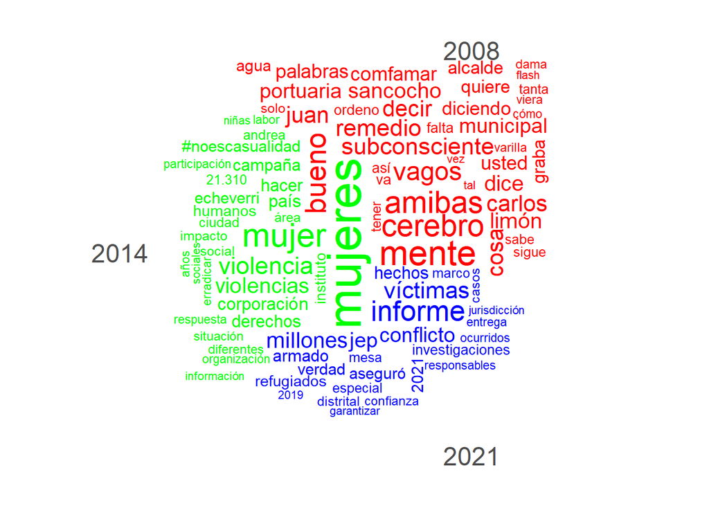

```r
# Gráfico de frecuencia de palabras controlando por años
corpus_subset(corp_text, year %in%c(2008,2014,2021)) %>%
    tokens(remove_punct = TRUE) %>%
    tokens_remove(c(stopwords("spanish"),eliminar)) %>%
    dfm() %>%
    dfm_group(groups = year) %>%
    dfm_trim(min_termfreq = 5, verbose = FALSE) %>%
    textplot_wordcloud(comparison = TRUE,max_words=150,
                        color = c('red',  'green','blue'))
```

El conflicto armado en la ciudad de Buenaventura se viene presentado desde finales de los año 90’, sin embargo, según las nubes de palabras, en el año 2008 las palabras relacionadas con violencia o conflicto no fueron las más frecuente. Mientras que en los años 2014 y 2021 resaltan las palabras relacionadas violencia. Este resultado, permite mostrar la dinámica del conflicto en la ciudad Buenaventura, es decir, no es homogéneo en el tiempo.

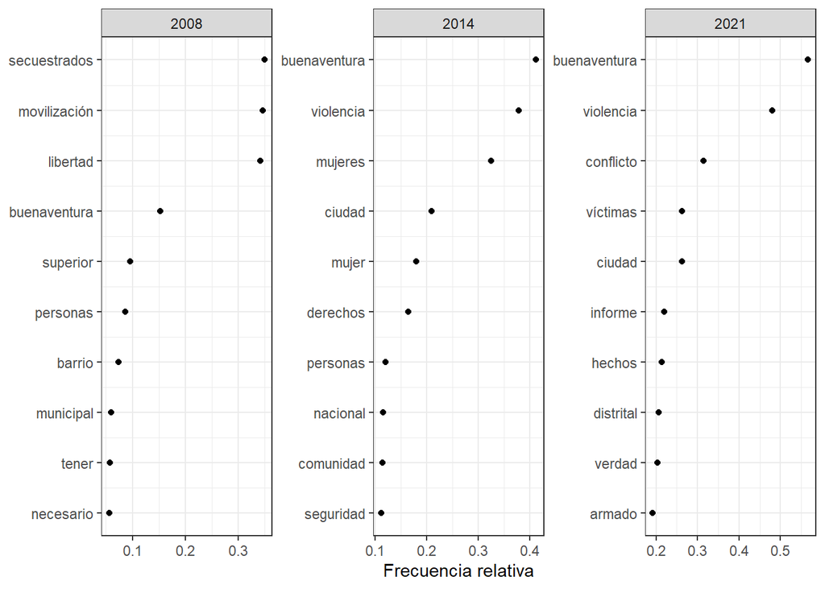

```r
dfm_pesp_corp_text <- corp_text %>%
  corpus_subset(year %in% c(2008,2014,2021)) %>%
  tokens(remove_punct = TRUE) %>%
  tokens_remove(c(stopwords("spanish"),eliminar)) %>%
  dfm() %>%
  dfm_weight(scheme = "prop")


# Frecuencia relativa
freq_peso <- textstat_frequency(dfm_pesp_corp_text, n = 10,
                                  groups = dfm_pesp_corp_text$year)

ggplot(data = freq_peso, aes(x = nrow(freq_peso):1, y = frequency)) +
     geom_point() +
     facet_wrap(~ group, scales = "free") +
     coord_flip() +
     scale_x_continuous(breaks = nrow(freq_peso):1,
                        labels = freq_peso$feature) +
     labs(x = NULL, y = "Frecuencia relativa")+
  theme_bw()
```

Este resultado confirma que efectivamente el peso de conflicto tuvo mayor relevancia entre los años 2014 y 2021. Ya que noticias relacionadas con la violencia como seguridad, hechos, derechos, armados entre otras tienen mayor peso relativo.

```r
tokens<-tokens(dfm_btura08_21_, remove_punct = TRUE, remove_numbers = TRUE)
tokens <- tokens_remove(tokens, c('de','para','en','la','a','lo','con','que','todos','han','y','se','es'))
kable(textstat_collocations(tokens, min_count = 20))
```

| collocation | count | count_nested | length | lambda | z |
| --- | --- | --- | --- | --- | --- |
| las mujeres | 88 | 0 | 2 | 4.556134 | 23.558423 |
| sisma mujer | 45 | 0 | 2 | 8.855394 | 18.068368 |
| las víctimas | 43 | 0 | 2 | 3.836422 | 17.019711 |
| los derechos | 36 | 0 | 2 | 4.134775 | 16.260103 |
| fuerza pública | 24 | 0 | 2 | 9.412190 | 16.134077 |
| del conflicto | 31 | 0 | 2 | 4.131201 | 15.556158 |
| corporación sisma | 20 | 0 | 2 | 8.156223 | 14.796944 |
| más mujeres | 20 | 0 | 2 | 3.847711 | 14.672792 |
| contra las | 26 | 0 | 2 | 3.391866 | 13.036135 |
| un llamado | 21 | 0 | 2 | 5.673479 | 12.554816 |
| conflicto armado | 36 | 0 | 2 | 10.135720 | 11.794086 |
| derechos humanos | 33 | 0 | 2 | 9.713224 | 11.381680 |
| el gobierno | 24 | 0 | 2 | 3.178121 | 11.048168 |
| las autoridades | 20 | 0 | 2 | 4.680561 | 10.914898 |
| el alcalde | 20 | 0 | 2 | 4.180125 | 9.765553 |
| el país | 20 | 0 | 2 | 2.776275 | 9.655300 |
| violencia sexual | 21 | 0 | 2 | 7.799398 | 9.188187 |
| por el | 36 | 0 | 2 | 1.289802 | 7.144432 |
| el marco | 24 | 0 | 2 | 7.071012 | 4.948356 |

Unos de los resultados más importante del trabajo fue identificar una posible relación entre violencia y mujer.Según los informes sobre conflicto armado en la ciudad Buenaventura, las mujeres fueron afectadas directamente en el contexto de la guerra. Violaciones, asesinatos y desapariciones son las denuncias más recurrentes. A pesar de que este trabajo tiene un carácter descriptivo sus resultados son insumo importante para una investigación posterior.

```r
s1 <- dfm_btura08_21_f %>%
  quanteda.textstats::textstat_simil(selection ="violencia",
  margin = "features", method = "correlation")
kable(as.list(s1, n=8))
```

|  | x |
| --- | --- |
| niña | 0.8516425 |
| bogotá | 0.8357416 |
| mujer | 0.8349799 |
| área | 0.8199898 |
| reforma | 0.8186423 |
| discriminación | 0.8171432 |
| lanzará | 0.8171432 |
| #noescasualidad | 0.8171432 |

#### Conclusión

El conflicto armado se ha percibido como las confrontaciones entre hombres, a pesar de la presencia de mujeres en los diferentes grupos armados irregulares. Ahora bien, las mujeres son victimas directas de la guerra. Las muertes o desapariciones de sus hijos(as),violaciones sexuales en el conflicto entre otras cosas atroces son recurrentes en las guerras pero son invisibilizadas . Estos resultados previos advierten la necesidad de explorar las todas relaciones y consecuencias del conflicto armado en las mujeres de la ciudad de Buenaventura.

#### Biblografía

Agudelo, C. E. (2001). El Pacífico colombiano: de remanso de paz a escenario estratégico del conflicto armado. Cuadernos de desarrollo Rural, 46, 7–37.

Escobar, A. (2004). Desplazamientos, desarrollo y modernidad en el Pacífico colombiano. En Restrepo y Rojas (Eds.), Conflicto e (in) visibilidad. Retos en los estudios de la gente negra en Colombia (1 ed, pp. 53-72) Editorial Universidad del Cauca.

Palacios, M (2012). Violencia publica en Colombia, 1958-2010. Bogotá, Colombia: FCE.